# CAUSE

March 12, 2017

## Principle 1: Blur the lines between lecture and lab

## Anectode

While in lab section…

[figure not shown]

## Then and Now

- Segregated lecture/lab is a legacy of when:
  - Desktops reigned
  - Proprietary statistical software was often the best/only option
- Today
  - Almost all students have access to laptops
  - Open source software options are more palatable

## Images

[figure not shown]

## Images

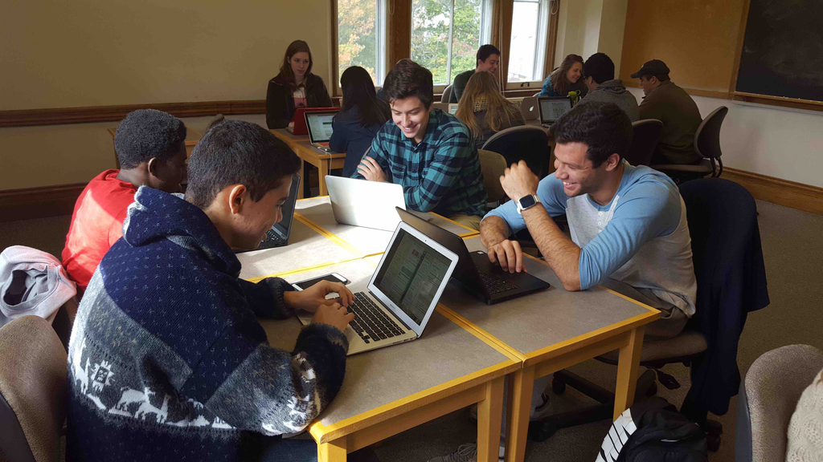

## Insipiration

From my 300-level Mathematical Statistics Theory of Statistics:

[figure not shown]

## Insipiration

- Permutation tests are very intuitive
- Bootstrap takes a little more work
- Can avoid long march to Central Limit Theorem

## Principle 5: Don't fence off students from the computation pool, throw them in!

## Something Bigger than Stats

- Forget Venn diagrams delineating Math vs CS vs Stats vs Data Science. If we blew up legacies and started over, what would we teach?
- Computational logic and algorithmic thinking are paramount to statistics/data science
- **Something bigger**: Very soon, coding will be a basic skill on par with reading and writing.

## Easier said than done

- Repeat this mantra ad nauseum: "Computers are stupid!"
- R has come a long way: ecosystem online, packages, and DataCamp
- Present students with this choice of what Cobb terms the "computational engine" of statistics:

This…

Or this…

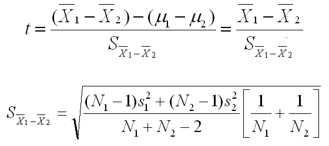

[figure not shown]